# Time Series and Classification project - First project

Amira BOUDAOUD

# **INTRODUCTION:**

### **the main aim of the project:**

The primary goal of this project is to accurately forecast the total ticket sales (measured in billions) by date for the cinema industry. Achieving this objective will empower stakeholders to make informed decisions regarding resource allocation, project planning, and strategic development, ultimately fostering sustainable growth and financial health within the industry.

### **Importance of Forecasting:**

Forecasting in the cinema industry is crucial because it:

- Directly influences budgetary and production decisions by providing a clear picture of expected revenue.
- Allows for the strategic allocation of resources, ensuring that investments are directed towards areas with the highest potential for growth.
- Facilitates continuous strategic planning, enabling stakeholders to refine pricing, product development, and marketing strategies based on anticipated sales trends.

In this notebook, we will be utilizing time series analysis to forecast total sales with this sample dataset.

# **Data Preparation and exploration**

in this section we will do Data Transformation:Analysis, Normalizing, standardizing, or applying transformations to stabilize variance.

- before starting let’s load all the necessary librairies used along this project

```r
#install.packages("tseries")
#library(tseries)
#install.packages("forecast")
#library(forecast)
#install.packages("TSA")
#library(TSA)
#install.packages("stats")
#library(stats)
#install.packages("Metrics")
#library(Metrics)
```

```r
#load the dataset
dataset <- read.csv("cinemaTicket_Ref.csv")
```

```r
#print the first 5 rows of the data
head(dataset)
```

```
##   film_code cinema_code total_sales tickets_sold tickets_out show_time
## 1      1492         304     3900000           26           0         4
## 2      1492         352     3360000           42           0         5
## 3      1492         489     2560000           32           0         4
## 4      1492         429     1200000           12           0         1
## 5      1492         524     1200000           15           0         3
## 6      1492          71     1050000            7           0         3
##   occu_perc ticket_price ticket_use capacity       date month quarter day
## 1      4.26       150000         26 610.3286 2018-05-05     5       2   5
## 2      8.08        80000         42 519.8020 2018-05-05     5       2   5
## 3     20.00        80000         32 160.0000 2018-05-05     5       2   5
## 4     11.01       100000         12 108.9918 2018-05-05     5       2   5
## 5     16.67        80000         15  89.9820 2018-05-05     5       2   5
## 6      0.98       150000          7 714.2857 2018-05-05     5       2   5
```

```r
# Get the dimensions (number of rows and columns) of the data frame
dim(dataset)
```

```
## [1] 142524     14
```

```r
# Display basic information and summary statistics about the data
str(dataset)
```

```
## 'data.frame':    142524 obs. of  14 variables:
##  $ film_code   : int  1492 1492 1492 1492 1492 1492 1492 1492 1492 1492 ...
##  $ cinema_code : int  304 352 489 429 524 71 163 450 51 522 ...
##  $ total_sales : int  3900000 3360000 2560000 1200000 1200000 1050000 1020000 750000 750000 600000 ...
##  $ tickets_sold: int  26 42 32 12 15 7 10 5 11 4 ...
##  $ tickets_out : int  0 0 0 0 0 0 0 0 0 0 ...
##  $ show_time   : int  4 5 4 1 3 3 3 3 2 3 ...
##  $ occu_perc   : num  4.26 8.08 20 11.01 16.67 ...
##  $ ticket_price: num  150000 80000 80000 100000 80000 ...
##  $ ticket_use  : int  26 42 32 12 15 7 10 5 11 4 ...
##  $ capacity    : num  610 520 160 109 90 ...
##  $ date        : chr  "2018-05-05" "2018-05-05" "2018-05-05" "2018-05-05" ...
##  $ month       : int  5 5 5 5 5 5 5 5 5 5 ...
##  $ quarter     : int  2 2 2 2 2 2 2 2 2 2 ...
##  $ day         : int  5 5 5 5 5 5 5 5 5 5 ...
```

```r
summary(dataset)
```

```
##    film_code     cinema_code     total_sales         tickets_sold
##  Min.   :1471   Min.   : 32.0   Min.   :2.000e+04   Min.   :   1.0
##  1st Qu.:1485   1st Qu.:181.0   1st Qu.:1.260e+06   1st Qu.:  18.0
##  Median :1498   Median :324.0   Median :3.720e+06   Median :  50.0
##  Mean   :1519   Mean   :320.4   Mean   :1.235e+07   Mean   : 140.1
##  3rd Qu.:1556   3rd Qu.:474.0   3rd Qu.:1.110e+07   3rd Qu.: 143.0
##  Max.   :1589   Max.   :637.0   Max.   :1.263e+09   Max.   :8499.0
##
##   tickets_out         show_time        occu_perc       ticket_price
##  Min.   :  0.0000   Min.   : 1.000   Min.   :  0.00   Min.   :   483.9
##  1st Qu.:  0.0000   1st Qu.: 2.000   1st Qu.:  3.75   1st Qu.: 60000.0
##  Median :  0.0000   Median : 3.000   Median : 10.35   Median : 79454.2
##  Mean   :  0.2374   Mean   : 3.932   Mean   : 19.97   Mean   : 81234.6
##  3rd Qu.:  0.0000   3rd Qu.: 5.000   3rd Qu.: 28.21   3rd Qu.:100000.0
##  Max.   :311.0000   Max.   :60.000   Max.   :147.50   Max.   :700000.0
##                                      NA's   :125
##    ticket_use        capacity          date               month
##  Min.   :-219.0   Min.   :  -2.0   Length:142524      Min.   : 2.000
##  1st Qu.:  18.0   1st Qu.: 277.0   Class :character   1st Qu.: 5.000
##  Median :  50.0   Median : 525.7   Mode  :character   Median : 7.000
##  Mean   : 139.9   Mean   : 854.7                      Mean   : 6.777
##  3rd Qu.: 143.0   3rd Qu.:1039.0                      3rd Qu.: 9.000
##  Max.   :8499.0   Max.   :9692.1                      Max.   :11.000
##                   NA's   :125
##     quarter           day
##  Min.   :1.000   Min.   : 1.00
##  1st Qu.:2.000   1st Qu.: 8.00
##  Median :3.000   Median :16.00
##  Mean   :2.635   Mean   :16.11
##  3rd Qu.:3.000   3rd Qu.:24.00
##  Max.   :4.000   Max.   :31.00
##
```

for our time series analysis we will forecast the total sales of the tickets in the cinema so all we need in our dataset is our target label “total_sales” and the date column (we could use the separate columns of day, quarter and month)

```r
#for our analysis we will start by the following:

# Sort the data by date
sorted_data <- dataset[order(dataset$date), ]

# Convert date column to Date object
sorted_data$date <- as.Date(sorted_data$date)
```

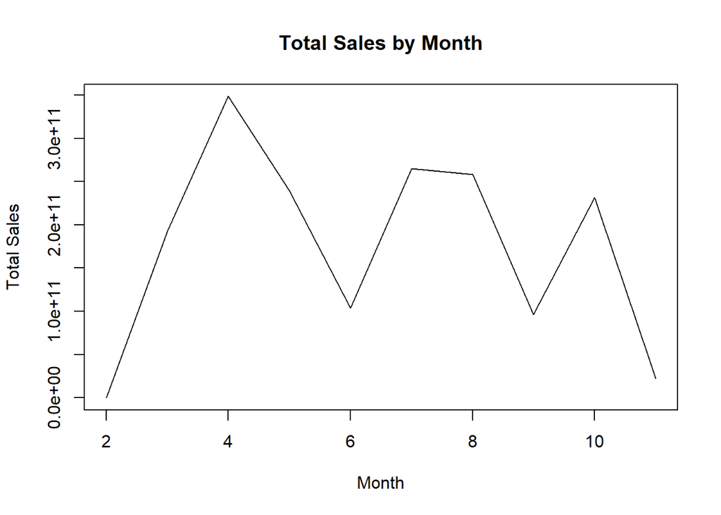

```r
# Plot total_sales aggregated by month
plot(aggregate(total_sales ~ month, data = sorted_data, sum), type = 'l', main = "Total Sales by Month", xlab = "Month", ylab = "Total Sales")
```

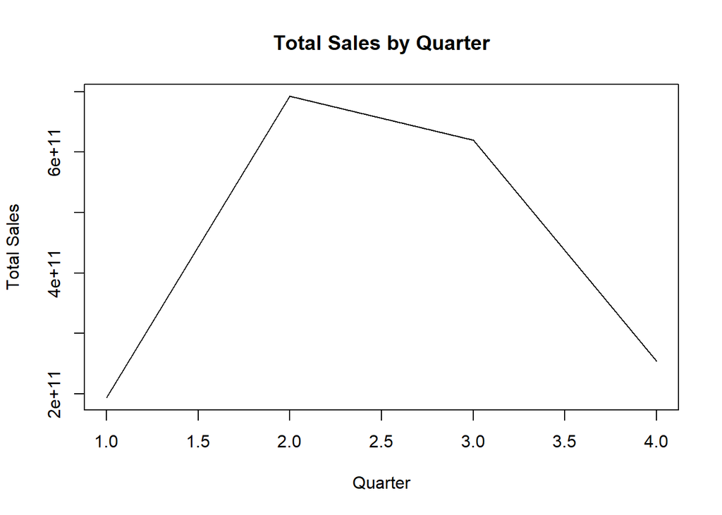

```r
# Plot total_sales aggregated by quarter
plot(aggregate(total_sales ~ quarter, data = sorted_data, sum), type = 'l', main = "Total Sales by Quarter", xlab = "Quarter", ylab = "Total Sales")
```

##### **interpretation of plotted data by quarter:**

Total sales exhibit higher values compared to the average during the second and third quarters. Specifically, at the onset of each quarter, there is a noticeable increase in sales, followed by a decline after the third quarter.

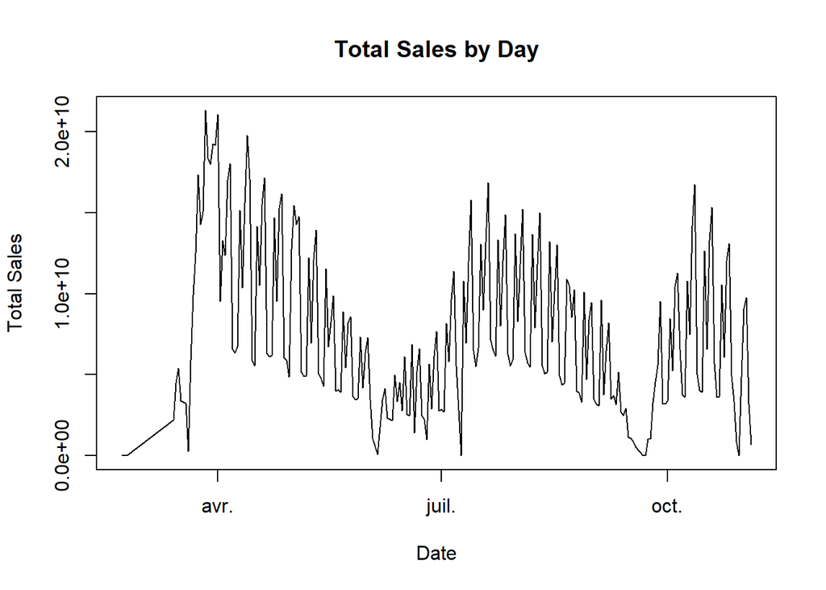

```r
# Plot total_sales aggregated by day
plot(aggregate(total_sales ~ date, data = sorted_data, sum), type = 'l', main = "Total Sales by Day", xlab = "Date", ylab = "Total Sales")
```

#### *interpretation of the plotted data by day (our time series data):*

**the reason for choosing the daily time series:** In our time series analysis and forecasting, we choose to use daily data because it provides a more detailed view of the temporal patterns in total sales. Daily data allows us to observe small changes and seasonal variations, helping us identify recurring patterns, trends, and anomalies more accurately. By using daily data in our analysis, we aim to improve the accuracy of our forecasting models by incorporating detailed insights into how sales behavior changes over time.

**initial analysis of the time series**: The time series clearly indicates non-stationary behavior, with evident fluctuations in sales volume over time. The data does not exhibit a clear long-term upward or downward trend, suggesting that any trends in the data are likely short-lived or obscured by the volatility of sales. There appear to be repeating patterns that hint at seasonality, likely corresponding to regular weekly cycles or monthly events, such as weekends or holidays when cinemas typically experience higher attendance. The variability in the data’s amplitude suggests changing variance, which may reflect periods of promotional activity, movie releases, or external factors affecting cinema attendance.

- Althought just visualizing the data is not enough, therefore we use the Dicky-Fuller test (ADF test or the Unit root test) to mathematically prove our dataset is not stationary.

```r
# Sort the data by date
ticket_df <- dataset[order(dataset$date), ]

# Convert date column to Date object
ticket_df$date <- as.Date(ticket_df$date)

# Aggregate total_sales by day
daily_sales <- aggregate(total_sales ~ date, data = ticket_df, sum)

# Create a new dataset containing only 'date' and 'total_sales' columns
ticket_df <- data.frame(date = daily_sales$date, total_sales = daily_sales$total_sales)

# Print the head of the new dataset and its dimension
head(ticket_df)
```

```
##         date total_sales
## 1 2018-02-21    32030000
## 2 2018-02-23      180000
## 3 2018-03-14  2202300484
## 4 2018-03-15  4479008974
## 5 2018-03-16  5386645987
## 6 2018-03-17  3367302992
```

```r
dim(ticket_df)
```

```
## [1] 234   2
```

- first, let’s split our dataset into training and testing sets
- the training is used for model specification and the testing is for model evaluation and validation

```r
# splitting the data into training and testing sets
n_test <- 30 #we took 30 instances for testing
train_data <- head(ticket_df, -n_test)
dim(train_data)
```

```
## [1] 204   2
```

```r
test_data <- tail(ticket_df, n_test)
dim(test_data)
```

```
## [1] 30  2
```

### *Stationarity test - Augmented Dickey-Fuller Test (ADF) :*

```r
library(tseries)
# Perform the Augmented Dickey-Fuller (ADF) test on the 'total_sales' column of the 'ticket_df' dataset
adf_result <- adf.test(train_data$total_sales)

# Print the results
print(adf_result)
```

```
##
##  Augmented Dickey-Fuller Test
##
## data:  train_data$total_sales
## Dickey-Fuller = -3.2667, Lag order = 5, p-value = 0.07827
## alternative hypothesis: stationary
```

- The test results indicate that the p-value associated with the test statistic is 0.07827. This p-value is greater than the significance level of 0.05, suggesting that we fail to reject the null hypothesis (that the data has a unit root, indicating non-stationarity). Therefore, in this case, we cannot reject the null hypothesis, implying that the time series is indeed non-stationary.

### *Approaches to normalize the data:*

To achieve stationarity in the dataset,we will implement normalization procedures. Commonly employed techniques for this purpose include Logarithmic Transform and then Difference Transform.

### *Logarithmic Transform - Box-Cox transformation:*

The logarithmic transform involves taking the natural logarithm of each observation, thereby converting the data into a logarithmic scale. Based on our previous time series representation, where the variance was observed to fluctuate over time, we primarily employ this transformation to stabilize the variance in the data. Additionally, it aids in reducing skewness, resulting in a more symmetric distribution. Given that our dataset appears far from being stationary, I will opt for logarithmic values to mitigate the need for higher-order transformations.

```r
# Perform log transformation on the 'total_sales' column
train_data$log_total_sales <- log(train_data$total_sales)

# Print the head of the dataset to verify the transformation
head(train_data)
```

```
##         date total_sales log_total_sales
## 1 2018-02-21    32030000        17.28218
## 2 2018-02-23      180000        12.10071
## 3 2018-03-14  2202300484        21.51277
## 4 2018-03-15  4479008974        22.22267
## 5 2018-03-16  5386645987        22.40719
## 6 2018-03-17  3367302992        21.93738
```

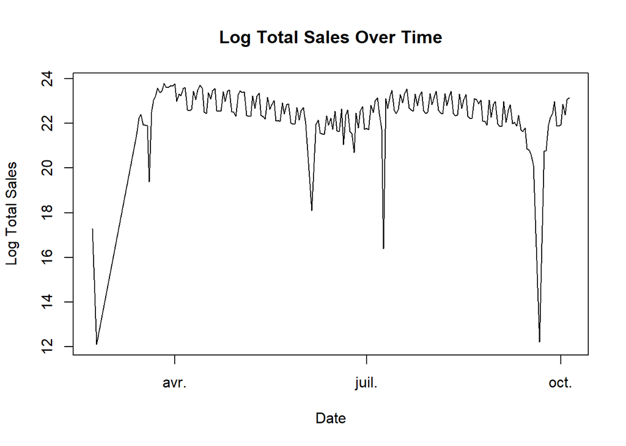

```r
# Plot data after applying logarithm transformation
plot(train_data$date, train_data$log_total_sales, type = 'l', col = 'black',
    xlab = 'Date', ylab = 'Log Total Sales', main = 'Log Total Sales Over Time')
```

- after applying logarithmic transformation, we clearly notice some peaks in the data which may be due to ouliers.

##### *plotting the ACF of the transformed data (after applying Box Cox transformation) to see the need of differencing:*

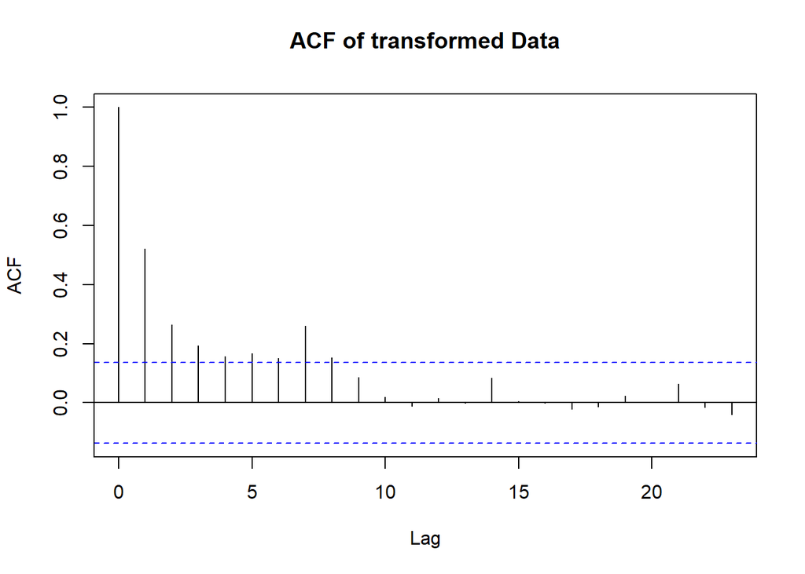

```r
acf(train_data$log_total_sales, main = "ACF of transformed Data")
```

- The ACF shows a decaying pattern, suggesting that the data requires differencing.

### *difference transformation:*

- To eliminate trends and pattern in datasets, we have to stabalize the mean of the time series.
- Difference transform takes datapoints at current time ‘t’ and and subtracts it with a point before (i.e ‘t-n’) resulting in a dataset between points at time ‘t’.

```r
# Define a function to carry out the difference transform
difference_transform <- function(df, order) {
  if (order == 1) {
    df$difference_order_1 <- c(NA, diff(df$log_total_sales))
    new_df <- df[, c("date", "difference_order_1")]
    colnames(new_df)[2] <- "total_sales_diff"
    plot(new_df$date, new_df$total_sales_diff, type = 'l', col = 'blue', main = 'Differenced Time Series - Order 1', xlab = 'Date', ylab = 'Total Sales Difference')
  } else if (order == 2) {
    df$t_minus_1 <- c(NA, df$log_total_sales[-nrow(df)])
    df$first_order_dt <- df$log_total_sales - df$t_minus_1
    df$first_order_dt_minus_1 <- c(NA, df$first_order_dt[-nrow(df)])
    df$target_order_dt <- df$first_order_dt - df$first_order_dt_minus_1
    new_df <- df[, c("date", "target_order_dt")]
    colnames(new_df)[2] <- "total_sales_diff"
    plot(new_df$date, new_df$total_sales_diff, type = 'l', col = 'red', main = 'Differenced Time Series - Order 2', xlab = 'Date', ylab = 'Total Sales Difference')
  } else if (order == 3) {
    df$t_minus_1 <- c(NA, df$log_total_sales[-nrow(df)])
    df$first_order_dt <- df$log_total_sales - df$t_minus_1
    df$first_order_dt_minus_1 <- c(NA, df$first_order_dt[-nrow(df)])
    df$second_order_dt <- df$first_order_dt - df$first_order_dt_minus_1
    df$second_order_dt_minus_1 <- c(NA, df$second_order_dt[-nrow(df)])
    df$target_order_dt <- df$second_order_dt - df$second_order_dt_minus_1
    new_df <- df[, c("date", "target_order_dt")]
    colnames(new_df)[2] <- "total_sales_diff"
    plot(new_df$date, new_df$total_sales_diff, type = 'l', col = 'green', main = 'Differenced Time Series - Order 3', xlab = 'Date', ylab = 'Total Sales Difference')
  } else {
    stop("Order should be 1, 2, or 3")
  }

  return(new_df)
}
```

```r
# Apply first-order difference transform
ticket_df_order_1 <- difference_transform(train_data, order = 1)
```

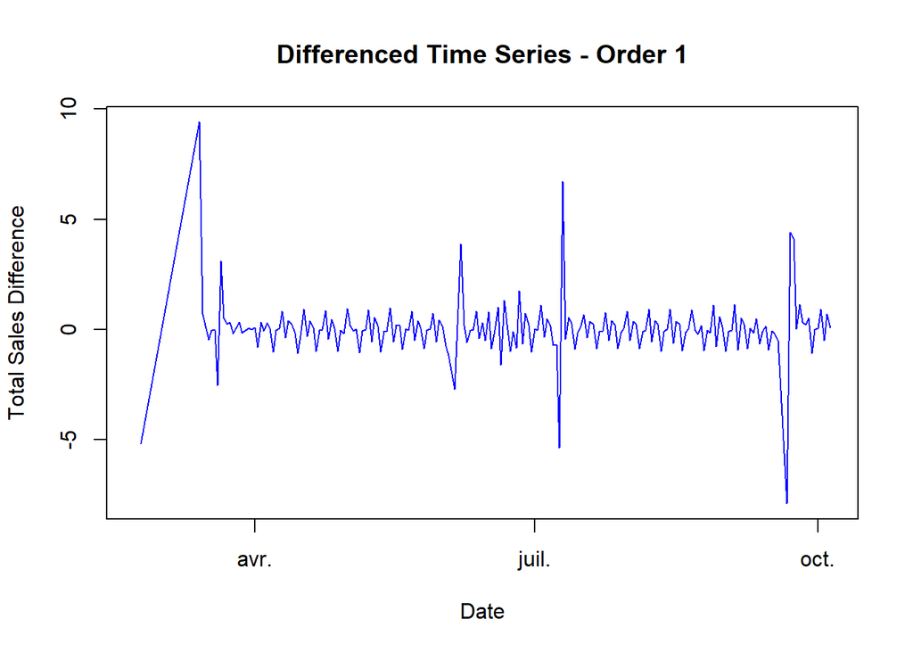

```r
head(ticket_df_order_1)
```

```
##         date total_sales_diff
## 1 2018-02-21               NA
## 2 2018-02-23       -5.1814714
## 3 2018-03-14        9.4120562
## 4 2018-03-15        0.7098993
## 5 2018-03-16        0.1845211
## 6 2018-03-17       -0.4698108
```

```r
# Apply second-order difference transform
ticket_df_order_2 <- difference_transform(train_data, order = 2)
```

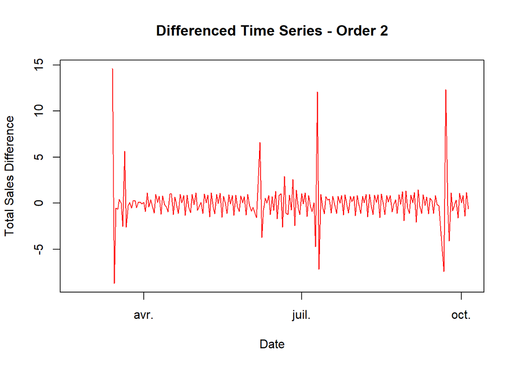

```r
head(ticket_df_order_2)
```

```
##         date total_sales_diff
## 1 2018-02-21               NA
## 2 2018-02-23               NA
## 3 2018-03-14       14.5935276
## 4 2018-03-15       -8.7021569
## 5 2018-03-16       -0.5253782
## 6 2018-03-17       -0.6543319
```

```r
# Apply third-order difference transform
ticket_df_order_3 <- difference_transform(train_data, order = 3)
```

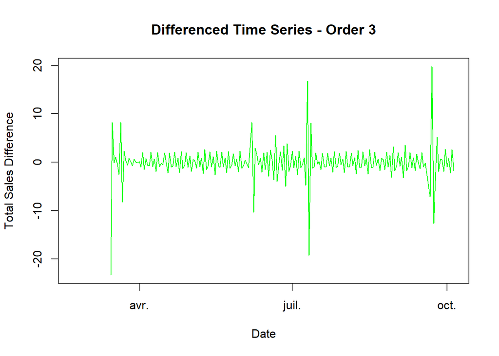

```r
head(ticket_df_order_3)
```

```
##         date total_sales_diff
## 1 2018-02-21               NA
## 2 2018-02-23               NA
## 3 2018-03-14               NA
## 4 2018-03-15      -23.2956845
## 5 2018-03-16        8.1767787
## 6 2018-03-17       -0.1289537
```

- The initial observation indicates that applying the first-order transformation to the logarithmic values of total sales renders the dataset appearing more stationary compared to the original dataset. The aim behind employing second and third-order differencing is to further enhance the stationarity of the time series data by removing trends and periodic fluctuations (but it seems that differenicng with order 1 is enough).
- Now we will check again the stationarity of our data using ADF test

```r
print("check stationarity of order 1")
```

```
## [1] "check stationarity of order 1"
```

```r
ticket_df_order__1 <- na.omit(ticket_df_order_1)
adf_result <- adf.test(ticket_df_order__1$total_sales)
# Print the results
print(adf_result)
```

```
##
##  Augmented Dickey-Fuller Test
##
## data:  ticket_df_order__1$total_sales
## Dickey-Fuller = -10.652, Lag order = 5, p-value = 0.01
## alternative hypothesis: stationary
```

##### **Remarks:**

Since the p-value (0.01) is less than the significance level (typically 0.05), we reject the null hypothesis. Therefore, we have evidence to suggest that the first-order differenced time series data is stationary, indicating that it does not exhibit a trend or systematic pattern over time. This suggests that the differencing operation effectively removed any trend from the original data, making it suitable for time series analysis and forecasting.

```r
# we will rename our differenced dataset
train_data_diff <- ticket_df_order__1
head(train_data_diff)
```

```
##         date total_sales_diff
## 2 2018-02-23      -5.18147139
## 3 2018-03-14       9.41205620
## 4 2018-03-15       0.70989932
## 5 2018-03-16       0.18452111
## 6 2018-03-17      -0.46981080
## 7 2018-03-18      -0.02063172
```

# **Forecasting with ARIMA:**

### *1-Finding the Best parameters for our ARMA(p,q) model:*

#### **plot the ACF and PACF of the data:**

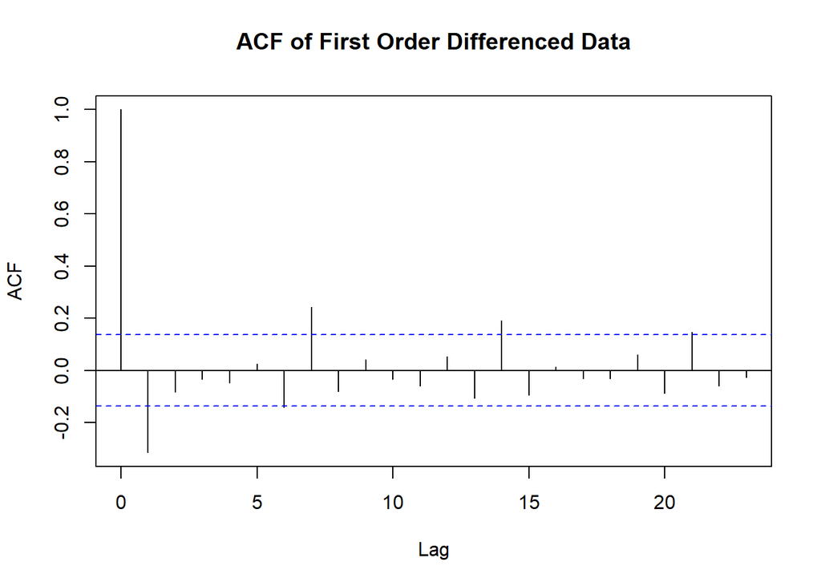

```r
# Plot ACF
acf(train_data_diff$total_sales_diff, main = "ACF of First Order Differenced Data")
```

#### **ACF interpretation :**

- we notice a correlation at lag 1.
- The correlations appear to taper off quickly after the initial lag, which suggests that the differenced series might not require a high number of MA terms.
- Thus, an initial suggestion for the order (q) would be q = 1. This indicates an MA(1) model.
- we can also notice a seasonal pattern (every 7 lags) in the acf plot,this is due to the seasonality of our dataset,it will be handled later on.

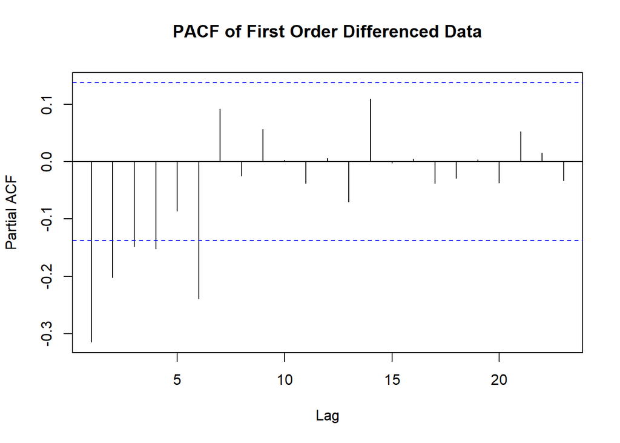

```r
# Plot PACF
pacf(train_data_diff$total_sales_diff, main = "PACF of First Order Differenced Data")
```

#### **PACF interpretations:**

- The first lag value (lag 1) has the highest absolute value and is outside the confidence interval, indicating a significant correlation between the differenced data at lag 1 and the previous value (lag 0). This suggests an autoregressive (AR) model of order 1 (AR(1)) might be appropriate
- Potential Higher AR Orders: Observing that the PACF values are significant up to lag 6 so we find it worthwhile to explore higher autoregressive (AR) orders. While this doesn’t imply a strict requirement to include these orders in our modeling, investigating higher AR orders can assist in capturing any lingering autocorrelations present in the data.

##### **plotting BIC chart:**

We start by plotting the armasubsets object to get a BIC chart ranking competing ARMA models according to their BIC (the model with the least BIC value is the best)

```r
library(TSA)
# Fit ARMA subset models
arma_subsets <- armasubsets(train_data_diff$total_sales_diff, 10, 10)
```

```
## Reordering variables and trying again:
```

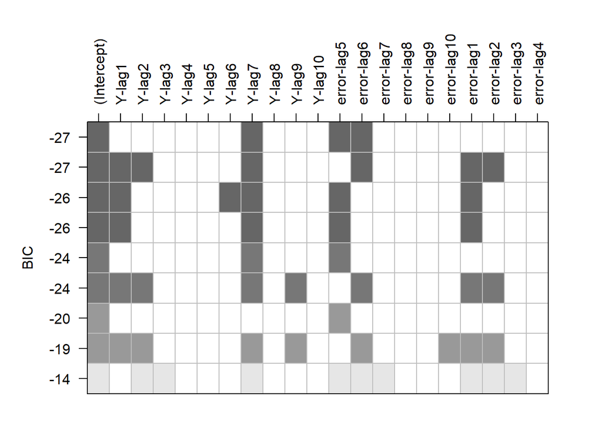

```r
# Plot the best subset models
plot(arma_subsets, labels = arma_subsets$xnames,
    scale = "BIC",
    col = gray(c(seq(0.4, 0.7, length = 10), 0.9)), draw.grid = TRUE)
```

- The BIC results suggest that the best model, as shown by the lowest BIC score of -27, seems to be the one that takes into account the 7th lag of the time series data and the 6th lag of the error terms, pointing towards an ARMA(7,6) model. A model with a similar BIC score also considers the 7th lag of the series and the 6th lag of errors, indicating that ARMA models with orders (p, q) of (7,6), and possibly (1,2) or (2,1) alternatively, could be good fits for the data, with each model including an intercept. Therefore, it would be prudent to take all these possible model orders into account when choosing the best ARMA model for our analysis.

##### **for the AIC (Akaike’s Information Criterion) and using the auto.arima function:**

```r
library(forecast)
# Fit ARIMA model using auto.arima
auto_arima_fit <- auto.arima(train_data_diff$total_sales_diff, start.p = 1, start.q = 1, max.p = 7, max.q = 6,
                            seasonal = FALSE, trace = TRUE, stepwise = TRUE)
```

```
##
##  Fitting models using approximations to speed things up...
##
##  ARIMA(1,0,1) with non-zero mean : 676.3094
##  ARIMA(0,0,0) with non-zero mean : 713.5637
##  ARIMA(1,0,0) with non-zero mean : 679.108
##  ARIMA(0,0,1) with non-zero mean : 679.7972
##  ARIMA(0,0,0) with zero mean     : 711.6114
##  ARIMA(2,0,1) with non-zero mean : 608.7416
##  ARIMA(2,0,0) with non-zero mean : 629.9899
##  ARIMA(3,0,1) with non-zero mean : Inf
##  ARIMA(2,0,2) with non-zero mean : Inf
##  ARIMA(1,0,2) with non-zero mean : 664.0248
##  ARIMA(3,0,0) with non-zero mean : 623.0843
##  ARIMA(3,0,2) with non-zero mean : Inf
##  ARIMA(2,0,1) with zero mean     : 606.6391
##  ARIMA(1,0,1) with zero mean     : 674.7033
##  ARIMA(2,0,0) with zero mean     : 628.0218
##  ARIMA(3,0,1) with zero mean     : 599.0818
##  ARIMA(3,0,0) with zero mean     : 621.0552
##  ARIMA(4,0,1) with zero mean     : Inf
##  ARIMA(3,0,2) with zero mean     : Inf
##  ARIMA(2,0,2) with zero mean     : 599.7143
##  ARIMA(4,0,0) with zero mean     : 615.5415
##  ARIMA(4,0,2) with zero mean     : 601.1433
##
##  Now re-fitting the best model(s) without approximations...
##
##  ARIMA(3,0,1) with zero mean     : 674.7935
##
##  Best model: ARIMA(3,0,1) with zero mean
```

```r
# Print the model summary
print(summary(auto_arima_fit))
```

```
## Series: train_data_diff$total_sales_diff
## ARIMA(3,0,1) with zero mean
##
## Coefficients:
##          ar1      ar2      ar3      ma1
##       0.3326  -0.0303  -0.0532  -0.7986
## s.e.  0.1475   0.1011   0.1057   0.1329
##
## sigma^2 = 1.572:  log likelihood = -332.24
## AIC=674.49   AICc=674.79   BIC=691.06
##
## Training set error measures:
##                      ME     RMSE       MAE     MPE    MAPE      MASE
## Training set 0.08417565 1.241293 0.7151047 2.76225 396.021 0.5997334
##                     ACF1
## Training set -0.01028906
```

##### interpretation of the results:

- The model selection process identified an ARIMA(3,0,1) model without a constant term as the best fit for the differenced data, indicated by the lowest AIC (and BIC values). This model implies that the current value of the series is related to its previous three values and the error term is influenced by one past error. The model’s accuracy metrics, like MAE and RMSE, suggest that on average, the predictions are fairly close to the actual values, but the extremely high MAPE indicates potential issues with the data or the model, possibly due to outliers or zero values. The near-zero ACF of the residuals suggests that there is no significant autocorrelation in the residuals, meaning the model is capturing the time series patterns well. However, for robust validation, the model’s predictive performance should be tested on unseen data.

### *summary and model specification results:*

- Considering the alignment of these results with those obtained from the PACF and ACF,the models that merit consideration are the following:
  - ARIMA(3,1,1): This model was selected by the auto.arima function for its low AIC and BIC values
  - ARIMA(7,1,6): Suggested by the BIC chart as a complex model that may capture deeper seasonal patterns due to the significant lags in both the AR and MA orders.
  - ARIMA(2,1,1): which is a simpler alternative that still take into account the significant initial lags observed in the PACF and ACF plots and could be a compromise between model complexity and performance.

```r
#selecting the ARIMA models based on the previous results
# taking in consideration the results of auto.arima
arima_model_311 <- Arima(train_data$total_sales, order = c(3, 1, 1))
#taking in consideration the results of BIC subplots
arima_model_716 <- Arima(train_data$total_sales, order = c(7, 1, 6))
#taking in consideration the results of ACF/PACF
arima_model_211 <- Arima(train_data$total_sales, order = c(2, 1, 1))
```

### *2-Residual analysis (model diagnostics):*

Plotting the residual which is the difference between the predicted data and the actual data allows us to visualize how well the model fit our data and check for any remaining patterns in the data.

```r
#define a function that does the model diagnostics
residual_analysis <- function(arima_model) {
  # Standardize residuals
  residuals <- arima_model$residuals / arima_model$sigma

  # Plot standardized residuals over time
  plot(residuals, type = "l", main = "Standardized Residuals Over Time")

  # QQ plot of standardized residuals
  qqnorm(residuals)
  qqline(residuals, col = "red")

  # ACF plot of the standardized residuals to check for autocorrelation
  acf(residuals, main="ACF of Standardized Residuals")

  # Histogram of standardized residuals
  hist(residuals, main="Histogram of Standardized Residuals", xlab="Standardized Residuals", breaks=30)

  # Ljung-Box test on standardized residuals for independence and randomness test
  box_test_results <- Box.test(residuals, type="Ljung-Box")
  print(box_test_results)

  # Shapiro-Wilk test for normality
  shapiro_test_results <- shapiro.test(residuals)
  print(shapiro_test_results)

  # Runs test for independence
  if(require(tseries)){
    runs_test_results <- runs.test(as.factor(sign(residuals)))
    print(runs_test_results)
  } else {
    cat("The 'tseries' package is not available. Please install it to perform runs test.")
  }
}
```

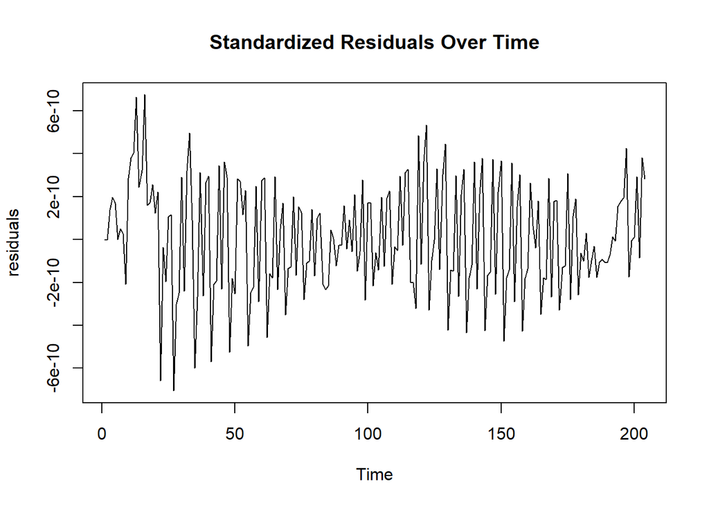

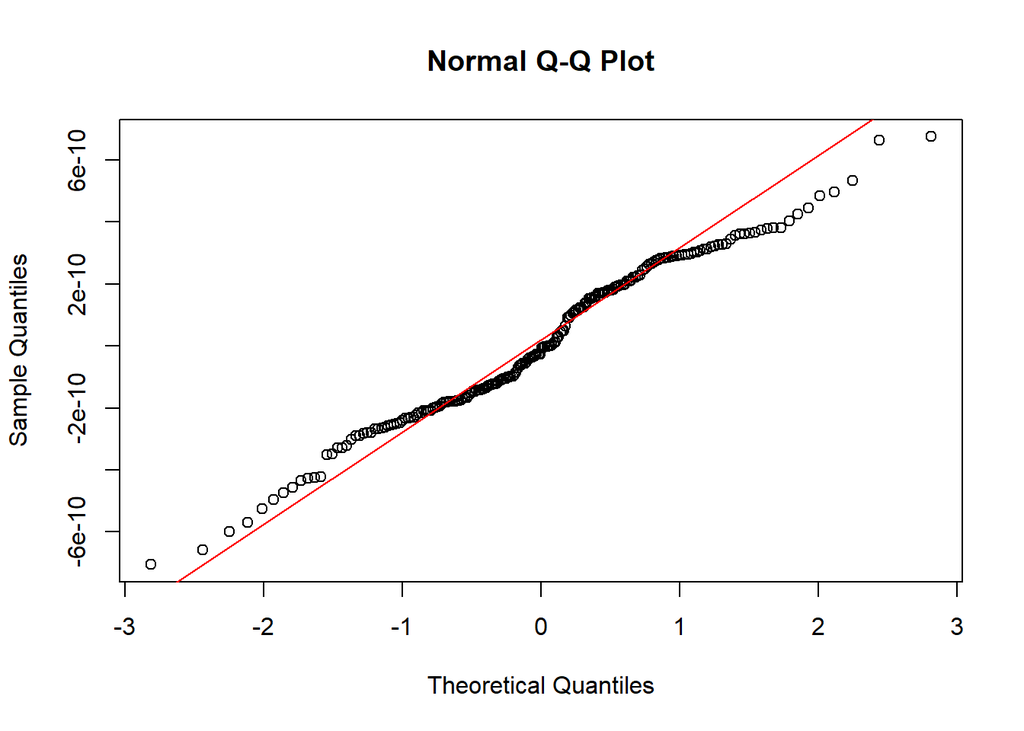

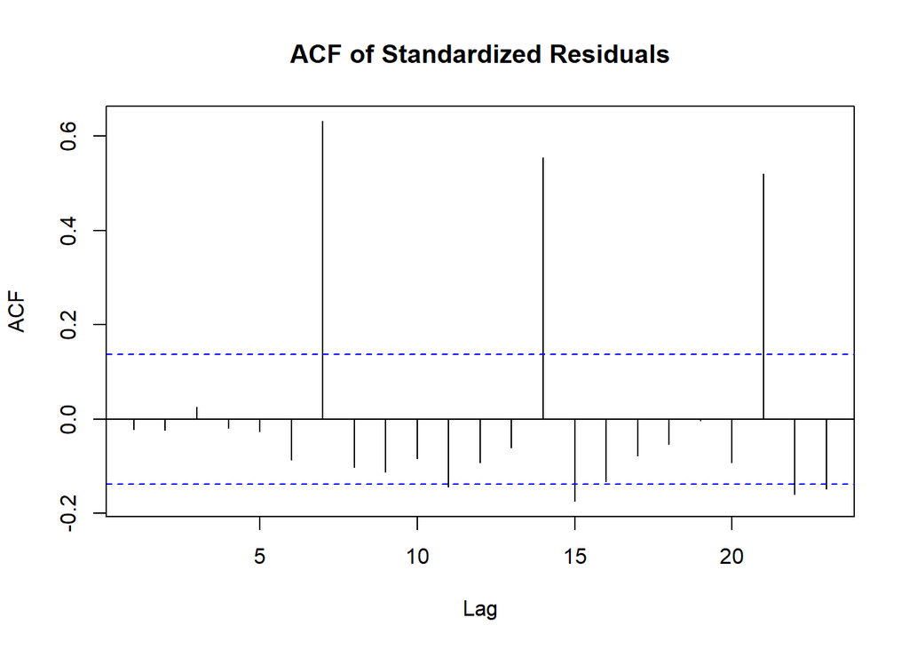

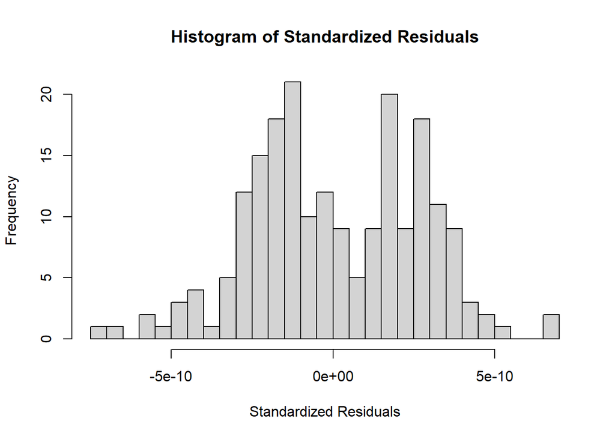

```
##
##  Box-Ljung test
##
## data:  residuals
## X-squared = 0.093079, df = 1, p-value = 0.7603
##
##
##  Shapiro-Wilk normality test
##
## data:  residuals
## W = 0.98157, p-value = 0.008904
##
##
##  Runs Test
##
## data:  as.factor(sign(residuals))
## Standard Normal = 0.022054, p-value = 0.9824
## alternative hypothesis: two.sided
```

```r
#implement our residualo test it on the selected models
residual_analysis(arima_model_311)
```

##### general results :

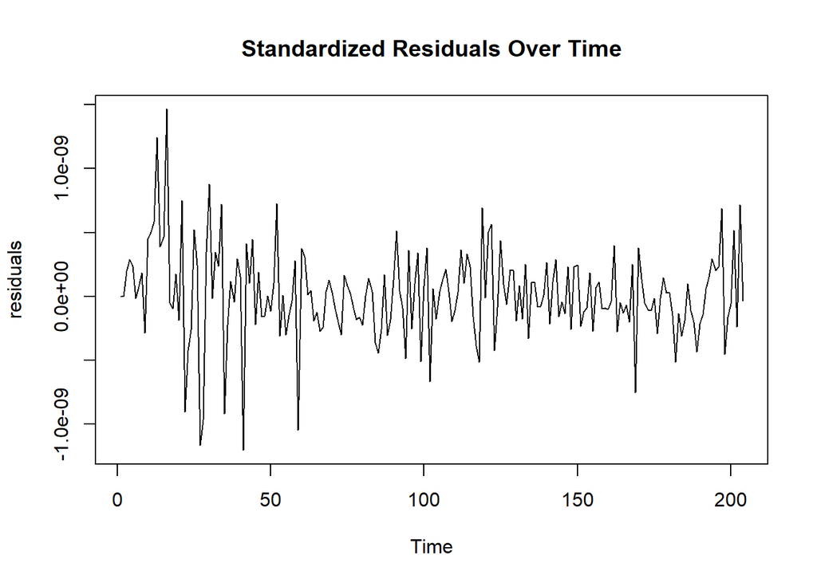

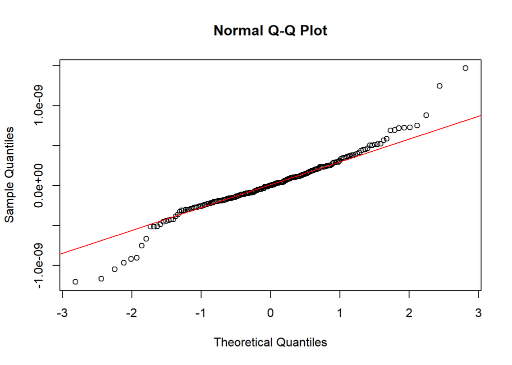

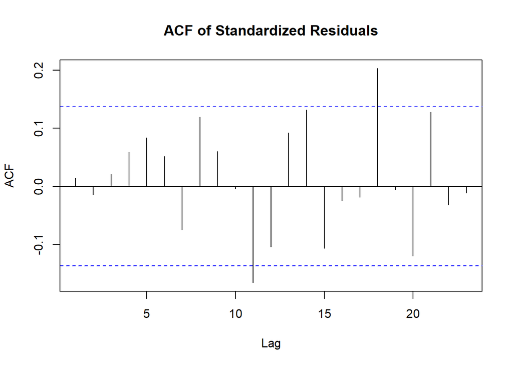

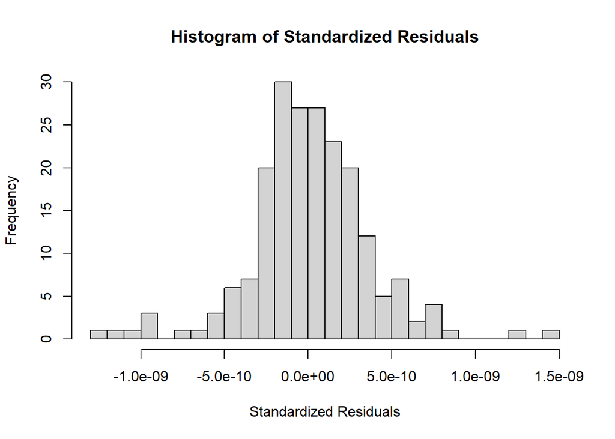

```
##
##  Box-Ljung test
##
## data:  residuals
## X-squared = 0.042456, df = 1, p-value = 0.8368
##
##
##  Shapiro-Wilk normality test
##
## data:  residuals
## W = 0.95589, p-value = 5.951e-06
##
##
##  Runs Test
##
## data:  as.factor(sign(residuals))
## Standard Normal = -0.41979, p-value = 0.6746
## alternative hypothesis: two.sided
```

```r
residual_analysis(arima_model_716)
```

##### **interpretations:**

- **Plot standardized residuals over time:** the residuals seem to be fluctuating around the zero line without a clear pattern, which is a good sign. However, there’s a noticeable upward trend at the beginning of the series, which might suggest the model has not fully captured some trend or seasonal effect.
- **QQ plot of standardized residuals:** most points lie on the line, but there are deviations at both ends, indicating potential heavy tails in the distribution of the residuals. This suggests some departures from normality, particularly with potential outliers or extreme values.
- **ACF plot of the standardized residuals:** The ACF plot shows that all autocorrelations are within the confidence intervals, which is a good sign, indicating no significant autocorrelations.
- **Histogram of standardized residuals:** The histogram is roughly bell-shaped but seems to be slightly skewed, indicating that the distribution of residuals is not perfectly symmetrical and might not be normal..
- **Ljung-Box test on standardized residual:** A high p-value (0.8368) suggests that there is no significant autocorrelation in the residuals, supporting the ACF findings.
- **Shapiro-Wilk test:** The p-value is very low (5.951e-06), leading us to reject the null hypothesis of normality. This suggests that the residuals are not normally distributed.
- **Runs test:** A high p-value (0.6746) indicates that we do not reject the null hypothesis, suggesting the data sequence is random, which supports the idea that the model is capturing the underlying process well.

#### general results:

The diagnostic tests and residual plots suggest that the ARIMA(7,1,6) model has done a reasonable job of capturing the information in the time series, as indicated by the randomness and lack of autocorrelation in the residuals. However, the potential non-normality of residuals and the slight visible trend in the residuals over time plot warrant further investigation. Additionally, validating the model on out-of-sample data (testing set) and considering other performance metrics would be important next steps in assessing the overall model fit.

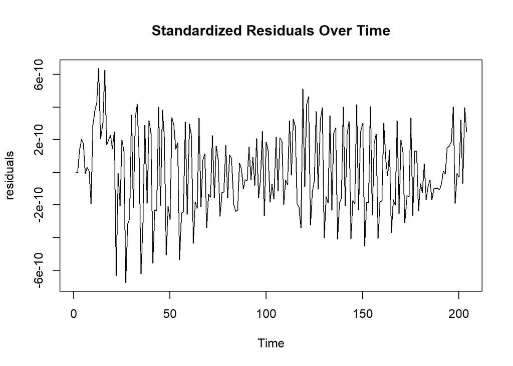

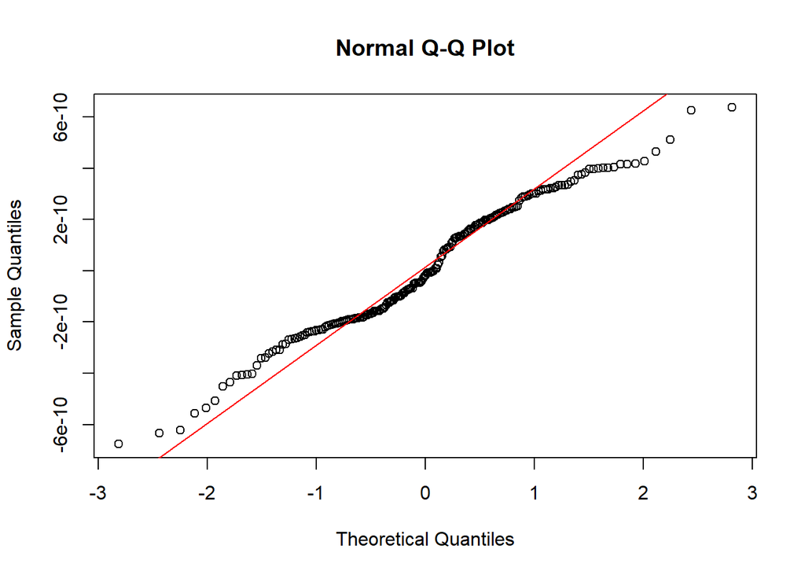

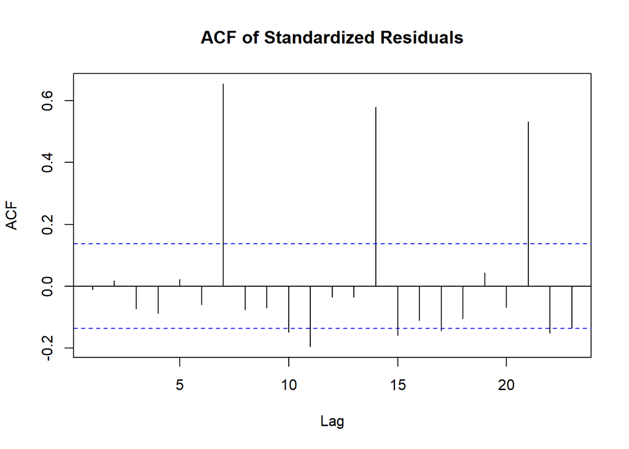

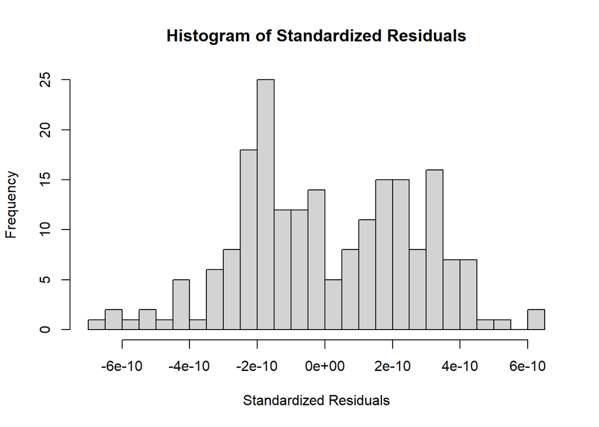

```
##
##  Box-Ljung test
##
## data:  residuals
## X-squared = 0.024688, df = 1, p-value = 0.8751
##
##
##  Shapiro-Wilk normality test
##
## data:  residuals
## W = 0.97808, p-value = 0.002818
##
##
##  Runs Test
##
## data:  as.factor(sign(residuals))
## Standard Normal = 0.33144, p-value = 0.7403
## alternative hypothesis: two.sided
```

```r
residual_analysis(arima_model_211)
```

##### **interpretations:**

the residuals’ plots show a similar behavious as the ones of the model ARIMA(3,1,1) with slight differences in the results of the different statistical tests

#### general results:

the residuals shows similar behavious for both models ARIMA(2,1,1) and ARIMA(3,1,1) thus we may take into account the one resulted from auto.arima which minimizes both BIC and AIC the ARIMA(3,1,1) model

### *Summary:*

-The lack of normality in the residuals could potentially be due to unmodeled seasonal patterns and outliers in the data, especially if the original time series displayed strong seasonal behavior that wasn’t accounted for in the ARIMA models. If the seasonal pattern is strong and systematic and there is remarkable outliers in the data, failing to model it would leave patterns in the residuals, which could manifest as non-normality and possibly some autocorrelation at seasonal lags.

#### **Prediction Plot :**

- Visualizing how well the models predicted value fits the actual data.
- we will plot the actual data and overlay the fitted values from the ARIMA models

```r
#define a function that plots the data and the fitted values from the models
plot_arima_fit <- function(arima_model) {
  library(forecast)

  # Ensure the date is in Date format
  train_data$date <- as.Date(train_data$date)

  # Extract the fitted values from the ARIMA model
  fitted_values <- fitted(arima_model)

  # Create a title that includes the name of the arima_model argument
  plot_title <- paste('Comparison between Original Data and', deparse(substitute(arima_model)), 'Model Fit')

  # Base R plot for actual data
  plot(train_data$date, train_data$total_sales, type = 'l', col = 'black',
       xlab = 'Time', ylab = 'Total Sales', main = plot_title)

  # Adding the fitted values from the ARIMA model to the plot
  lines(train_data$date, fitted_values, col = 'red')

  # Optionally, add a legend if desired
  legend("topright", legend = c("Actual", "Fitted"), col = c("black", "red"), lty = 1, bty = "n")
}
```

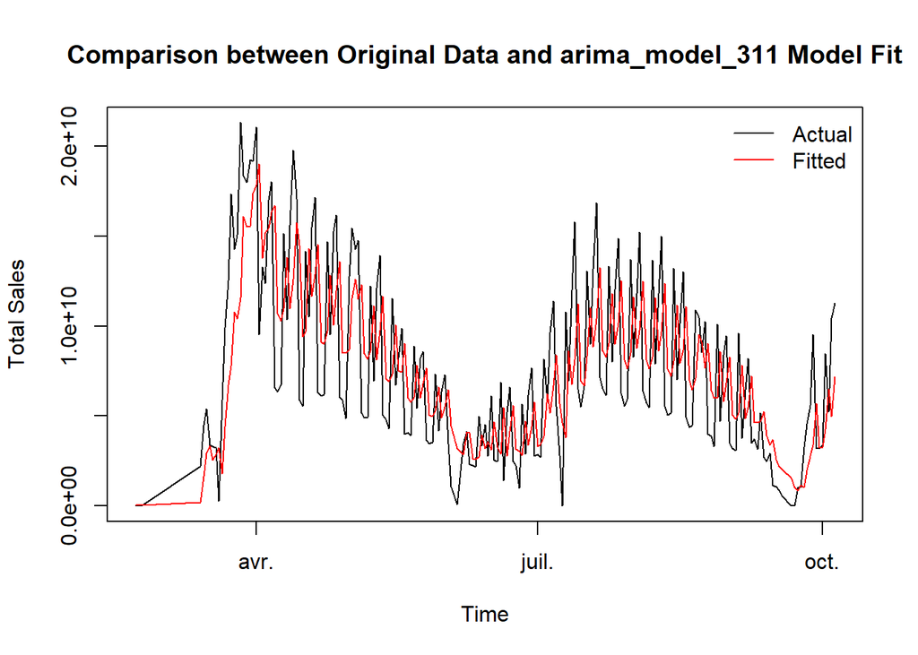

```r
#apply it on the chosen models
plot_arima_fit(arima_model_311)
```

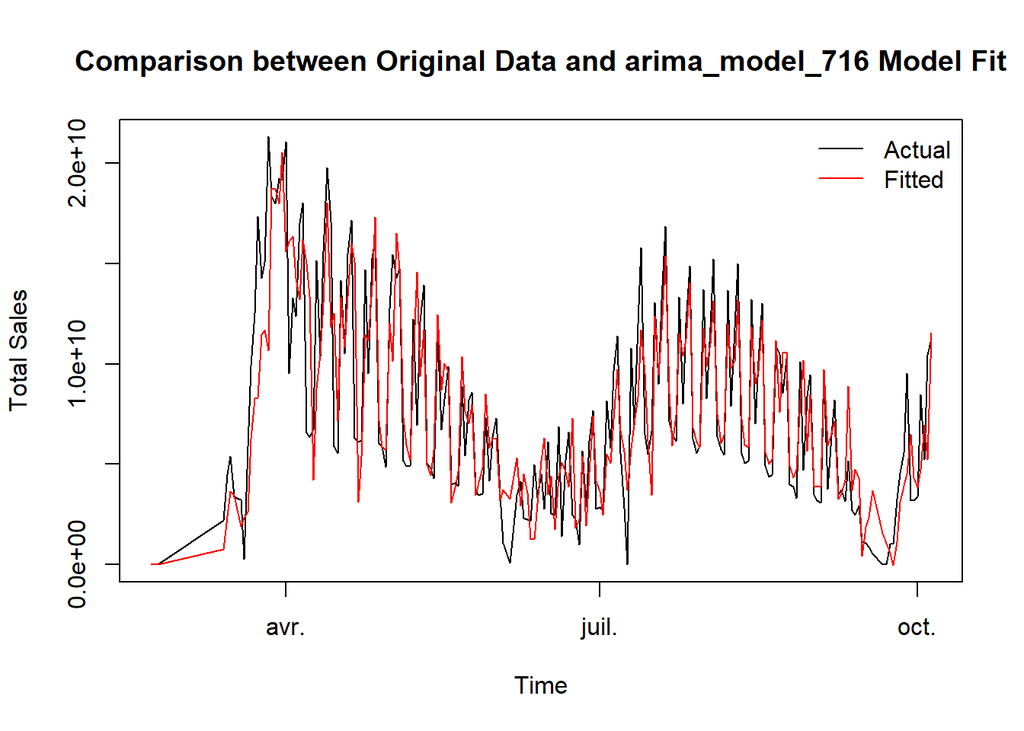

```r
plot_arima_fit(arima_model_716)
```

### *interpretation:*

- For ARIMA(3,1,1), the fitted values generally align with the trend of the actual data, but there are notable discrepancies. The model fails to capture some peaks and troughs present in the actual data, possibly due to outliers or abrupt changes that the model’s parameters are not equipped to handle effectively (low order). Consequently, the model tends to smooth over these irregularities, which is a common behavior observed in ARIMA models.
- In contrast, for ARIMA(7,1,6), the fitted values closely track the direction of the actual data. This indicates that the model effectively captures the primary patterns in the data and even manages to capture various fluctuations, including some outliers. The higher order of this model allows it to better adapt to the complexity of the data, resulting in a more accurate representation of the underlying patterns.
- In summary, while ARIMA(3,1,1) shows limitations in capturing certain features of the data, ARIMA(7,1,6) demonstrates better performance in capturing both the main trends and variations, making it a more suitable model for forecasting in this scenario, we will explore more regarding this in the forecasting part.

### *3-Forecasting:*

```r
evaluate_and_forecast_model <- function(model, training_dataset, test_set) {
  library(forecast)
  library(Metrics)

  # Ensure 'date' in training_dataset is Date type
  training_dataset$date <- as.Date(training_dataset$date)

  # Forecast the future values for the length of the test set
  forecast_length <- length(test_set$total_sales)
  forecast_results <- forecast(model, h = forecast_length)

  # Plot the original training data with bolder lines
  plot(training_dataset$date, training_dataset$total_sales, type = 'l', col = 'blue', lwd = 2, main = "Training Data and Forecasted Sales", xlab = "Date", ylab = "Sales")

  # Generate future dates for plotting the forecasted values
  forecast_dates <- seq(from = max(training_dataset$date) + 1, length.out = forecast_length, by = "day")

  # Add forecasted values to the plot in red color with bolder lines
  lines(forecast_dates, forecast_results$mean, col = "red", lwd = 2)

  # Add a legend with updated colors and line types
  legend("bottomleft", legend = c("Training Data", "Forecasted"), col = c("blue", "red"), lty = 1, lwd = 2, bty = "n")

  # Evaluation metrics calculation
  actual_values <- as.numeric(test_set$total_sales)
  predicted_values <- forecast_results$mean

  # Calculating evaluation metrics
  mae_val <- mae(actual_values, predicted_values)
  rmse_val <- rmse(actual_values, predicted_values)
  mape_val <- mape(actual_values, predicted_values)
  r_squared_val <- 1 - sum((actual_values - predicted_values)^2) / sum((actual_values - mean(actual_values))^2)

  # Print evaluation metrics
  cat("Evaluation Metrics:\n")
  cat("MAE:", mae_val, "\n")
  cat("RMSE:", rmse_val, "\n")
  cat("MAPE:", mape_val, "%\n")
  cat("R-squared:", r_squared_val, "\n")

  return(list(forecast = forecast_results$mean, MAE = mae_val, RMSE = rmse_val, MAPE = mape_val, R_squared = r_squared_val))

}
```

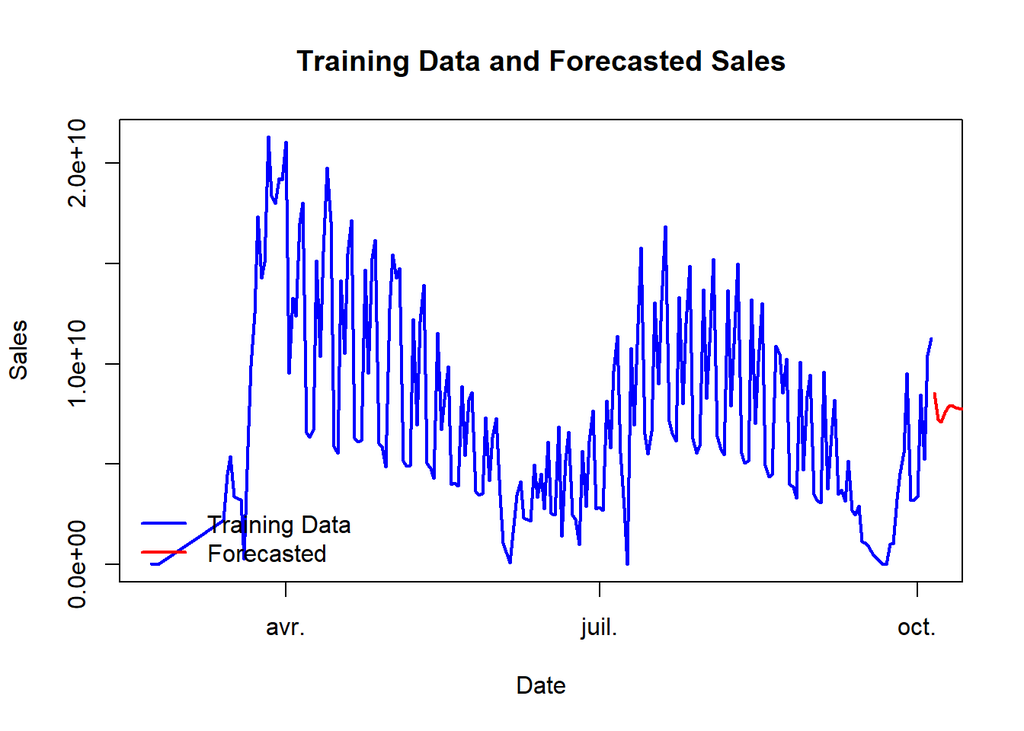

```
## Evaluation Metrics:
## MAE: 4050866569
## RMSE: 4562338667
## MAPE: 126.5924 %
## R-squared: -0.003405339
```

```
## $forecast
## Time Series:
## Start = 205
## End = 234
## Frequency = 1
##  [1] 8559264614 7211419280 7103309806 7608942284 7909577628 7932432763
##  [7] 7834204863 7769999232 7764202949 7783595415 7797099304 7798584991
## [13] 7794739921 7791917617 7791547140 7792309380 7792897314 7792987098
## [19] 7792836290 7792714083 7792692827 7792722582 7792747937 7792752877
## [25] 7792747026 7792741774 7792740642 7792741789 7792742875 7792743131
##
## $MAE
## [1] 4050866569
##
## $RMSE
## [1] 4562338667
##
## $MAPE
## [1] 126.5924
##
## $R_squared
## [1] -0.003405339
```

```r
#apply the function on our models
evaluate_and_forecast_model(arima_model_311,train_data, test_data)
```

#### interpretation :

The evaluation metrics for the ARIMA(3,1,1) model suggest that the model’s forecasts are not very accurate. The mean absolute error (MAE) is about 4.051 billion, and the root mean squared error (RMSE) is approximately 4.562 billion, which are quite large considering the scale of your data is in billions. A MAPE (mean absolute percentage error) of 126.59% is particularly high, indicating that, on average, the forecast is off by more than the actual value itself, which is not ideal.

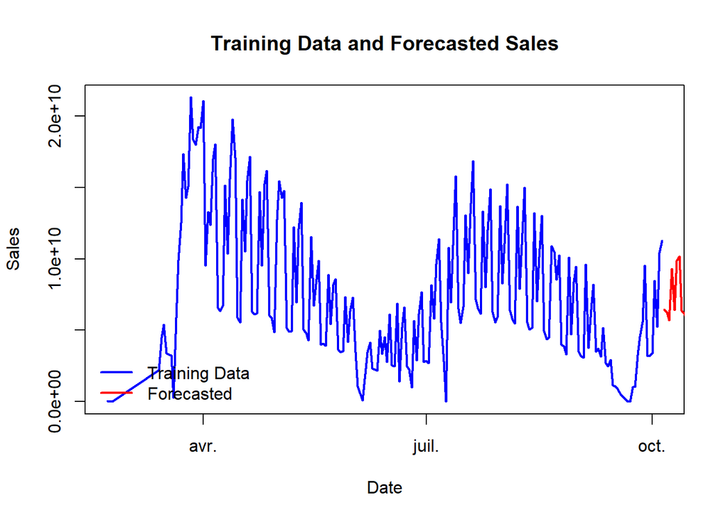

```
## Evaluation Metrics:
## MAE: 2859241488
## RMSE: 3437025280
## MAPE: 129.6798 %
## R-squared: 0.4305353
```

```
## $forecast
## Time Series:
## Start = 205
## End = 234
## Frequency = 1
##  [1]  6442158913  6256121446  5694343607  9299724394  6437567504  9883645110
##  [7] 10187131884  6371933253  6159644806  5859023020  8589469008  7254488296
## [13]  9440727346  9345668792  6304977158  6078557399  6034473523  8200359093
## [19]  7752338386  9079424167  8691396910  6242972426  6033204120  6215987755
## [25]  8005377870  8040455107  8771635063  8176877743  6190491708  6028552729
##
## $MAE
## [1] 2859241488
##
## $RMSE
## [1] 3437025280
##
## $MAPE
## [1] 129.6798
##
## $R_squared
## [1] 0.4305353
```

```r
evaluate_and_forecast_model(arima_model_716, train_data, test_data)
```

##### interpretation :

- MAE (Mean Absolute Error) is approximately 2.859 billion, which is a high error considering that the data scale is in billions. RMSE (Root Mean Squared Error) is about 3.437 billion, indicating that the forecasts have a considerable average deviation from the actual values.
- MAPE (Mean Absolute Percentage Error) is 129.68%, suggesting that the forecasted values, on average, deviate from the actual values by a margin larger than the actual values themselves, which is indicative of a poor fit.
- R-squared is 0.4305, showing that the model explains approximately 43.05% of the variance in the data, which is a moderate improvement compared to the ARIMA(3,1,1) model but still indicates a significant amount of variance is left unexplained. The actual forecast values range from 5.694 billion to over 10.187 billion, which seem to capture some of the variability in the data. However, the high MAE and RMSE, along with a very high MAPE, imply that the accuracy of the forecasts is still not satisfactory.
  - Comparing the ARIMA(7,1,6) to the ARIMA(3,1,1) model, the ARIMA(7,1,6) shows a lower MAE and RMSE, indicating better accuracy. The R-squared value also suggests a better fit to the data. However, the high MAPE values in both models are concerning and suggest that both models may not be capturing the data’s underlying process effectively.

##### Conclusion:

Although the ARIMA(7,1,6) model seems to perform better in terms of MAE, RMSE, and R-squared compared to the ARIMA(3,1,1) model, the forecasting accuracy for both models is not ideal, as indicated by the extremely high MAPE values. This could be due to various reasons such as nonlinearity in the data, the presence of outliers, regime changes, or other forms of non-stationarity that are not addressed by the models.

# **Forecasting with SARIMA :**

```r
#i took the best model from ARIMA and add the seasonality differencing so that i will have a SARIMA model
# note: I tried to do auto.arima and it gave me SARIMA(3,1,1) which performed very bad even with seasonal differencing

# Fit a SARIMA model explicitly setting seasonal parameters (P, D, Q)
# The 'order' is for the non-seasonal part (p, d, q), and 'seasonal' is for the seasonal part (P, D, Q, m)
sarima_model <- Arima(train_data$total_sales,
                      order = c(7, 1, 6),  # Non-seasonal parameters
                      seasonal = c(1, 1, 1),  # Seasonal parameters: (P, D, Q)
                      include.constant = FALSE,  # Typically we do not include a constant in a differenced model
                      method = "ML")

# Print the summary of the fitted model
summary(sarima_model)
```

```
## Series: train_data$total_sales
## ARIMA(7,1,6)
##
## Coefficients:
##           ar1      ar2      ar3      ar4      ar5      ar6     ar7      ma1
##       -0.1683  -0.2368  -0.2636  -0.2721  -0.1543  -0.1157  0.5682  -0.3030
## s.e.   0.3693   0.3359   0.3404   0.3457   0.3593   0.3283  0.2781   0.3778
##          ma2     ma3     ma4      ma5      ma6
##       0.0254  0.1901  0.1289  -0.0417  -0.1781
## s.e.  0.2006  0.2001  0.1770   0.2142   0.1714
##
## sigma^2 = 7.417e+18:  log likelihood = -4694.23
## AIC=9416.47   AICc=9418.7   BIC=9462.85
##
## Training set error measures:
##                    ME       RMSE        MAE       MPE     MAPE      MASE
## Training set 72789609 2628371217 1893724849 -2730.134 2756.309 0.5905757
##                     ACF1
## Training set 0.002933044
```

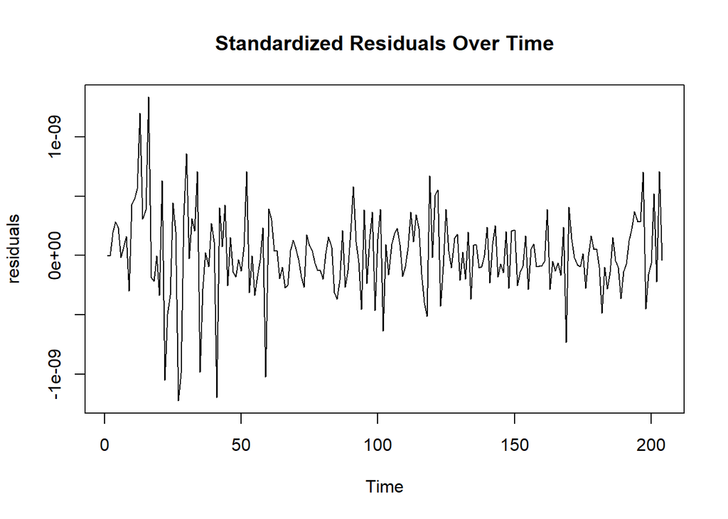

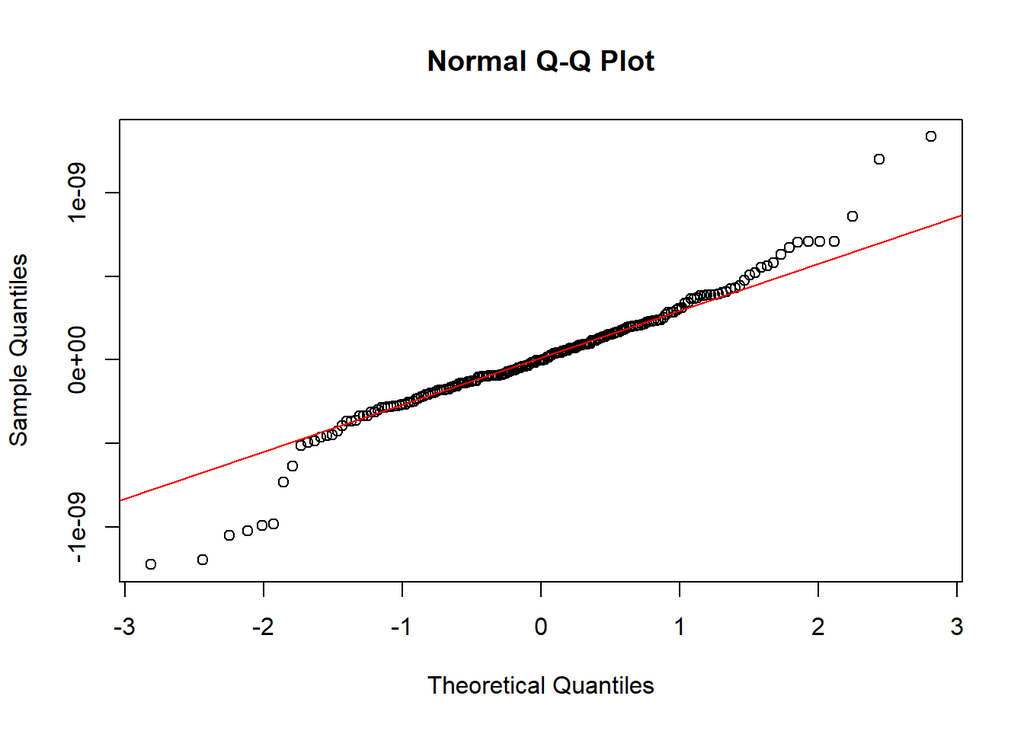

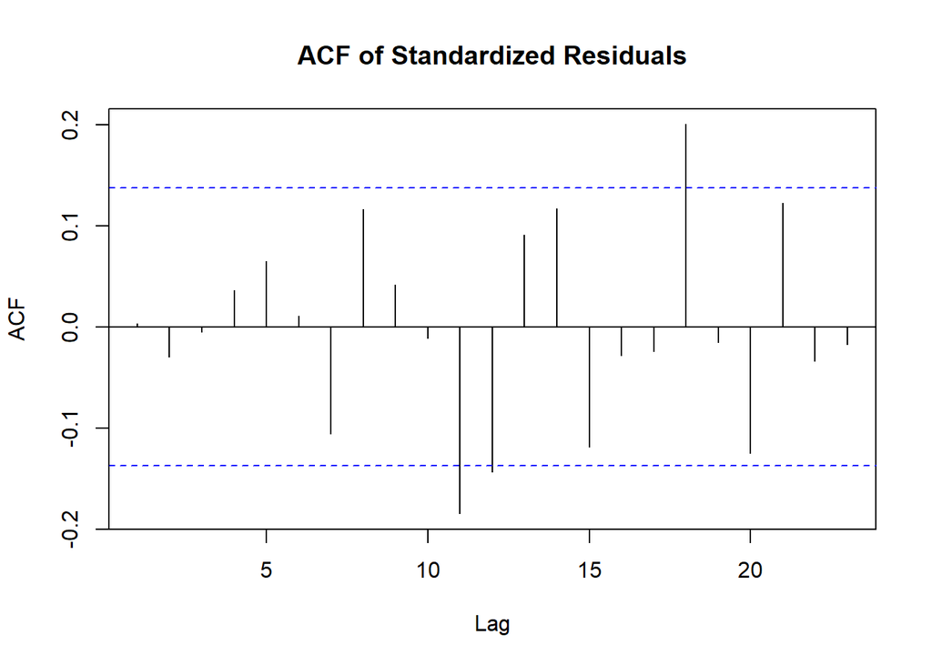

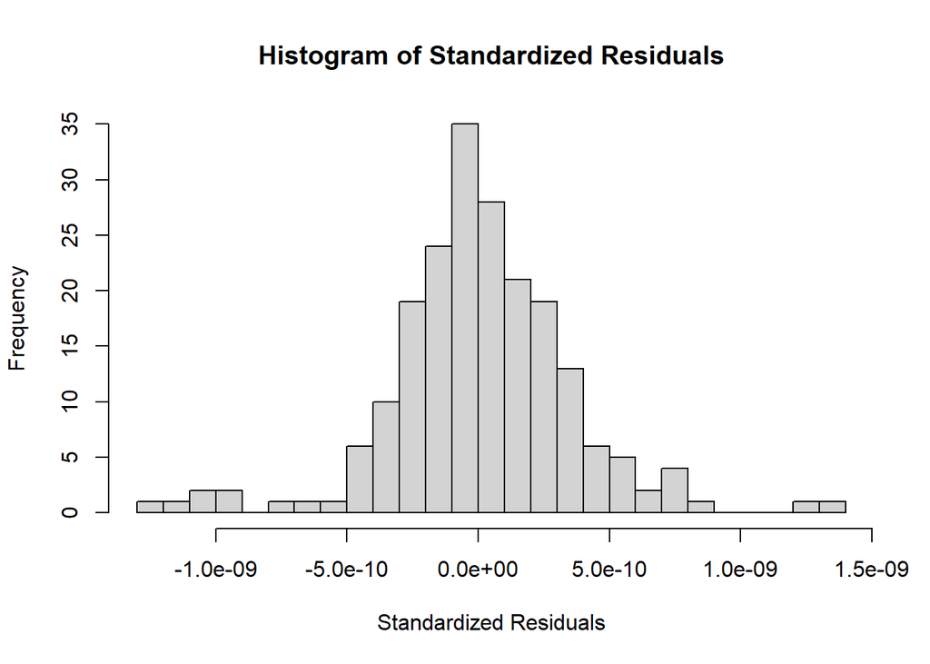

```
##
##  Box-Ljung test
##
## data:  residuals
## X-squared = 0.0017809, df = 1, p-value = 0.9663
##
##
##  Shapiro-Wilk normality test
##
## data:  residuals
## W = 0.95308, p-value = 3.071e-06
##
##
##  Runs Test
##
## data:  as.factor(sign(residuals))
## Standard Normal = -0.98134, p-value = 0.3264
## alternative hypothesis: two.sided
```

```r
residual_analysis(sarima_model)
```

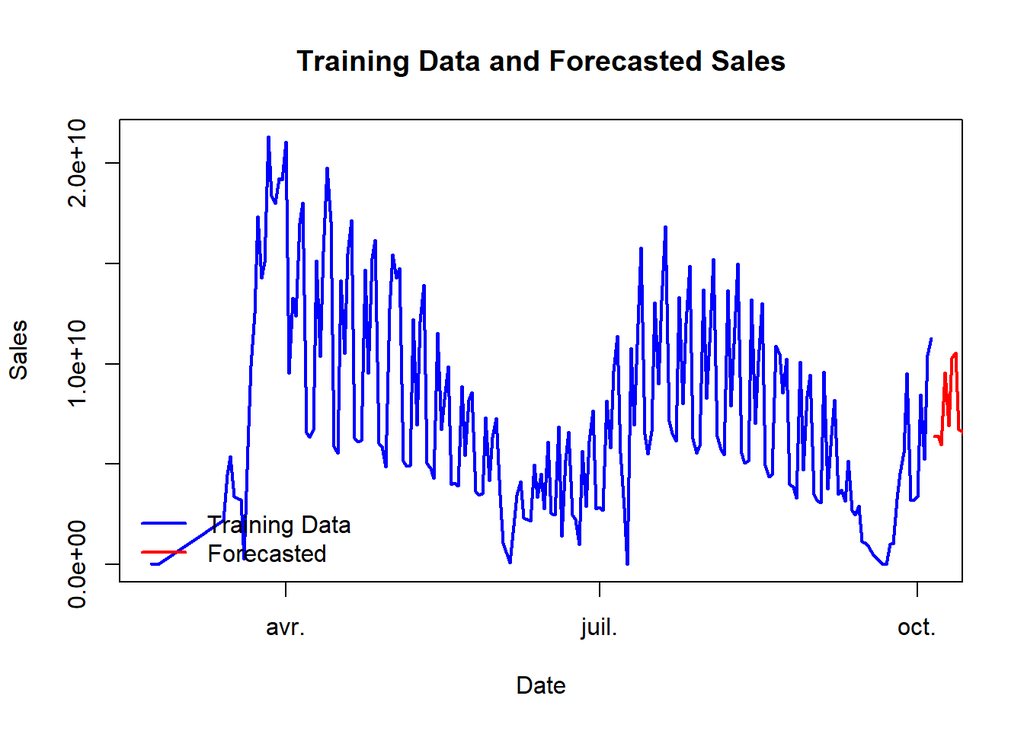

```
## Evaluation Metrics:
## MAE: 3002802711
## RMSE: 3581355595
## MAPE: 143.1482 %
## R-squared: 0.3817043
```

```
## $forecast
## Time Series:
## Start = 205
## End = 234
## Frequency = 1
##  [1]  6398583342  6412040604  5957116221  9589426640  6912411824 10295471702
##  [7] 10561728028  6726209405  6645100619  6310750355  9176205887  7884644370
## [13] 10016598588  9907051211  6863208378  6741328601  6609271158  8940952321
## [19]  8476548718  9764026356  9387506615  6939090672  6813557909  6890303765
## [25]  8834729041  8833859101  9540245585  8976974304  6987288266  6889347425
##
## $MAE
## [1] 3002802711
##
## $RMSE
## [1] 3581355595
##
## $MAPE
## [1] 143.1482
##
## $R_squared
## [1] 0.3817043
```

```r
evaluate_and_forecast_model(sarima_model, train_data, test_data)
```

#### general interpretation of the results :

##### **some advanced proposed solutions for that kind of datasets that can not be fitted well using ARIMA/SARIMA models:**

- Anomaly Detection and Correction: Identify and correct outliers, as they can have a disproportionate effect on model quality.
- Incorporate Exogenous Variables: If there are known factors or indicators that influence the forecasted variable, consider using ARIMAX or SARIMAX models which can include these exogenous variables.this solutions is possible since our original dataset contains many several other features that may be important.
- Nonlinear Models: Sometimes the data might have nonlinear patterns that ARIMA models cannot capture. In such cases, models like ARCH/GARCH (for volatility clustering) or neural network-based models might be more suitable.

#### **the reason why the models ARIMA/Sarima and other simple models could not show good and reasonable results in the context of this dataset**

- **Complex Seasonality Patterns:** The cinema industry exhibits complex seasonality, with ticket sales fluctuating based on holidays, blockbuster releases, and seasonal events. Traditional models like ARIMA and SARIMA may struggle to fully capture these patterns, especially when they are not regular or involve multiple seasonal cycles.
- **Impact of External Factors:** External factors such as screening time in each day, occupation percent of cinema ,price of ticket at show time and many other factors (other features in the dataset) can have significant, unpredictable impacts on ticket sales. Linear time series models typically do not incorporate external variables directly, limiting their ability to predict changes driven by these factors.
- **Data Complexity and Noise:** The dataset may contain noise and complexities such as ,outliers, or anomalies (e.g., exceptionally high ticket sales for blockbuster hits or significantly low sales due to unforeseen events). simple models, which often assume homoscedasticity and normally distributed errors, might be overly sensitive to these data issues, leading to poor predictions.

# **CONCLUSION:**

In the broader context of the project, the challenges in accurately forecasting ticket sales underscore the necessity of adopting more sophisticated, flexible modeling approaches that can accommodate the cinema industry’s unique dynamics. This may involve exploring non-linear models, incorporating external data sources, and leveraging other algorithms that can adapt to complex patterns and relationships within the data.Thus,fitting simple models (trigonometric trend components,ARIMA, or SARIMA) will not show raisonable results.